# Unit 02.B: Intro to R and RStudio

Instructor: Dr. Md Mutasim Billah

You can download the .qmd file for this activity here and open in R-studio. The rendered version is posted in the [course website](https://mutasim221b.github.io/CWRU-STAT-312-Fall-26/) (Activities tab).

I often experiment with the class activities (and see it in live!) and make updates, but I always post the final version before class starts. To be sure you have the most up-to-date copy, please download it once you’ve settled in before class begins.

# R and RStudio

## Example 1: Use R as a calculator

Type the following lines in the **console** (bottom left), one by one, hitting Return/Enter after each line. In some cases you might even get an error! This error is *important* to learning how R code does and doesn’t work.

```r
4 + 2
```

```r
4^2
```

```r
4*2
```

```r
4(2)
```

## Example 2: Functions and arguments

We can also use built-in **functions** to perform common tasks. These functions have *names* and require information about *arguments* in order to run:

`function(argument)` `Cheatcode: RiceCooker(Uncooked Rice)`

Try out the following functions *one by one* in the RStudio console. For each function, note its…

- *name*
- the *argument* or information it needs to run
- what *output* it produces (what the function *does*)
- how the name *connects* to what the function does

```r
sqrt(9)
```

```r
nchar("casewesternreserve")
```

```r
sqrt(nchar("snow"))
```

Some functions have *more than 1 argument*, separated by commas:

`function(argument1 = ___, argument2 = ___)` `Cheatcode: RiceCooker(Rice,Chicken)`

Try out the following, one by one.

```r
rep(x = 2, times = 5)
```

```r
rep(times = 5, x = 2)
```

```r
rep(2, 5)
```

```r
rep(5, 2)
```

Finally, R is case sensitive. Try using `Rep()` instead of `rep()`. Take time to read the **error message**!

```r
Rep(5, 2)
```

## Example 3: Save it for later

We’ll often want to store some R output for later use. In R:

`name <- output`

where `name` is the name under which to store a result, `output` is the result we wish to store, and `<-` is the **assignment operator** (I think of this as an arrow pointing the `output` into the `name`).

IMPORTANT: Try out each line *one at a time*. Why doesn’t the first line produce any output?

```r
degrees_c <- -13
```

```r
degrees_c
```

```r
degrees_c * (9/5) + 32
```

## Example 4: Import data

Next, let’s work with **data**!! The first step is importing our data into RStudio. How we do this depends on:

1. file format (eg: .xls Excel spreadsheet, .csv, .txt)
2. file location (eg: online, on your desktop, built into RStudio itself).

First, in the Console pane of RStudio, run the following command to install some necessary packages (you will need to do this any time you are installing a new package):

`install.packages("tidyverse")`

```r
# Load the "tidyverse" package which contains the read_csv() function
library(tidyverse)

# Import the data
survey <- read_csv("https://mutasim221b.github.io/CWRU-STAT-312-Fall-26/handout/fall_2025_survey.csv")
```

**Check out the data**

In the Environment tab in the upper right pane of RStudio, click on `survey`. What happens?!

In the modern era, datasets often contain hundreds of variables and millions of observations. We need more effective ways to explore such data.

## Example 5: Get to know the data

Before we can learn anything from our data, we must understand its structure.

```r
dim(survey) # (Number of row (case/obs.), Number of column (variable))
```

```r
nrow(survey) # Number of case/obs.
```

```r
ncol(survey) # Number of variables
```

```r
head(survey) # View first few rows of the dataset (6 rows, by default)
```

```r
head(survey, 3) # Controlling the view of first few rows of the dataset
```

```r
tail(survey) # View first few rows of the dataset (6 rows, by default)
```

```r
names(survey) # Get all column (variable) names
```

## Example 6 : Code = communication

It’s important to recognize from day 1 that **code is a form of communication**, both to yourself and others!!!!! Code structure and details are important to readability and clarity, just as grammar, punctuation, spelling, paragraphs, and line spacing are important in written essays. All of the code below *works*, but has bad structure.

```r
seq(from=1, to=9, by=2)
seq(from = 1, to=9, by=2)
temp_cel <- -13
thisisthetemperaturetodayincelsius <- -13
thisisthetemperaturetodayincelsius
this_is_the_temperature_today_in_celsius <- -13
this_is_the_temperature_today_in_celsius
```

## Example 7: You will make so many mistakes!

Mistakes are common when, and even *important* to, learning any new language. You’ll get better and better at interpreting error messages, finding help, and fixing errors. In addition to finding help online, R has built-in **help files**. For example:

- In the console, type `?rep` and press Return/Enter.
- Check out the documentation file that pops up in the Help tab (lower right).
- Quickly scroll through, noting the type of information provided.
- Pause at the “Examples” section at the bottom – perhaps the most useful section!

## Example 8: Make a “cheat sheet”

You’re highly encouraged to start tracking this in a cheat sheet (eg: in a Google doc). The cheat sheet will be a handy reference for you, and the act of making it will help deepen your understanding and retention.

# Descriptive Statistics

> **Guiding question:** What anxieties have been on Americans’ minds over the decades?

**Context:** *Dear Abby* is America’s longest running advice column. Started in 1956 by Pauline Phillips under the pseudonym Abigail van Buren, the column continues to this day under the stewardship of her daughter Jeanne. Each column features one or more letters to Abby from anonymous individuals, all signed with a pseudonym. Abby’s response follows each letter.

In 2018, the data journalism site [The Pudding](https://pudding.cool/) published a visual article called [30 Years of American Anxieties](https://pudding.cool/2018/11/dearabby/) in which the authors explored themes in Dear Abby letters from 1985 to 2017. (We only have the questions, not Abby’s responses.) The codebook is available [here](https://mutasim221b.github.io/CWRU-STAT-312-Fall-26/handout/dear_abby_codebook.pdf).

## Exercise 1: Importing and getting to know the data

First, in the **Console pane** of RStudio, run the following command to install some necessary packages (you will need to do this any time you are installing a new package):

```
install.packages("tidyverse") # Have you installed it?
```

Now, in the **Quarto pane**, run the following code chunk to load the package and load a dataset (you can either click the green arrow in the top right of the code chunk, put your cursor in the code chunk and hit Ctrl+Alt+C [on Windows/Linux] or Command+Option+C [on Mac]).

```r
# Load package
library(tidyverse)

# Read in the Dear Abby data
abby <- read_csv("https://mutasim221b.github.io/CWRU-STAT-312-Fall-26/handout/dear_abby.csv")
```

Throughout this activity, **we’ll work only with the most recent year of data, from 2017**. Run the following chunk (don’t worry about the codes!):

```r
# Wrangle the Dear Abby data
# Ignore this code for now!
abby <- abby %>%
  filter(year == 2017) %>%
  mutate(month = month(month, label = TRUE)) %>%
  mutate(
    parents = str_detect(question_only, "mother|mama|mom|father|papa|dad"),
    marriage = str_detect(question_only, "marriage|marry|married"),
    money = str_detect(question_only, "money|finance")
  ) %>%
  rowwise() %>%
  mutate(
    themes = c(
      if (parents) "parents",
      if (marriage) "marriage",
      if (money) "money"
    ) %>% paste(collapse = ", "),
    themes = ifelse(themes == "", "other", themes)
  ) %>%
  ungroup() %>%
  select(year, month, day, question_only, bing_pos, afinn_overall, afinn_pos, afinn_neg, themes)
```

```r
# ??? [what do both numbers mean?]
dim(abby)
## [1] 514   9
```

```r
# ???
nrow(abby)
## [1] 514
```

```r
# ???
ncol(abby)
## [1] 9
```

```r
# ???
head(abby)
## # A tibble: 6 × 9
##    year month day   question_only     bing_pos afinn_overall afinn_pos afinn_neg
##   <dbl> <ord> <chr> <chr>                <dbl>         <dbl>     <dbl>     <dbl>
## 1  2017 Aug   30    "i moved to the …    0.75             14        16         2
## 2  2017 Aug   30    "under what circ…   NA                NA        NA        NA
## 3  2017 Aug   28    "i'm not a dog p…    0.333             5         5         0
## 4  2017 Aug   28    "my 62-year-old …    0.143           -11         8        19
## 5  2017 Aug   27    "i have a friend…    0.222             0         7         7
## 6  2017 Aug   27    "i have been sel…    0.333            -5         2         7
## # ℹ 1 more variable: themes <chr>
```

```r
# ???
names(abby)
## [1] "year"          "month"         "day"           "question_only"
## [5] "bing_pos"      "afinn_overall" "afinn_pos"     "afinn_neg"
## [9] "themes"
```

## Exercise 2: Preparing to summarize and visualize the data

In the next exercises, we will be exploring themes in the Dear Abby questions and the overall “mood” or sentiment of the questions. Before continuing, read the [codebook](https://mutasim221b.github.io/CWRU-STAT-312-Fall-26/handout/dear_abby_codebook.pdf) for this dataset for some context about sentiment analysis, which gives us a measure of the mood/sentiment of a text.

1. What sentiment variables do we have in the dataset? Are they **quantitative** or **categorical**?

> The sentiment variables are `afinn_overall`, `afinn_pos`, `afinn_neg`, and `bing_pos`, and they are **quantitative**. The `afinn` variables don’t have units but we can still get a sense of the scale by remembering that each word gets a score between -5 and 5. The `bing_pos` variable doesn’t have units because it’s a fraction, but we know that it ranges from 0 to 1.
2. Check out the `theme` variable. Is this **quantitative** or **categorical**?

> **categorical**
3. What visualizations are appropriate for looking at the distribution of a single quantitative variable? What about a single categorical variable?

> Appropriate visualizations: (1) single quantitative variable: boxplot, histogram, density plot; (2) single categorical variable: barplot

## Exercise 3: Exploring themes in the letters

1. The code below makes a **barplot** of the `themes` variable using the `ggplot2` visualization package.

```r
# Load package
# install.packages("ggplot2") # Run in R Console first time to install (copy without '#')
library(ggplot2)

# barplot
ggplot(abby, aes(x = themes)) +
    geom_bar() +
    theme(axis.text.x = element_text(angle = 90, vjust = 0.5, hjust=1))
```

[output not shown]

2. We can follow up on the barplot with a simple numerical summary. Whereas the `ggplot2` package is great for visualizations, `dplyr` is great for numerical summaries. The code below constructs a table of the number of questions with each theme. Make sure that these numerical summaries match up with what you saw in the barplot.

```r
# install.packages("dplyr") # Run in R Console first time to install (copy without '#')
# Construct a table of counts
abby %>%
    count(themes)
## # A tibble: 8 × 2
##   themes                       n
##   <chr>                    <int>
## 1 marriage                    75
## 2 marriage, money              5
## 3 money                       21
## 4 other                      234
## 5 parents                    127
## 6 parents, marriage           33
## 7 parents, marriage, money     4
## 8 parents, money              15
```

3. Before proceeding, let’s break down the plotting code above. Run each chunk to see how the two lines of code above build up the plot in “layers”.

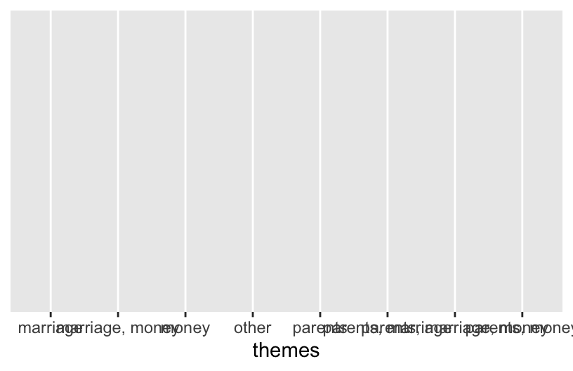

```r
# sets up the "canvas" of the plot with axis labels
ggplot(abby, aes(x = themes))
```

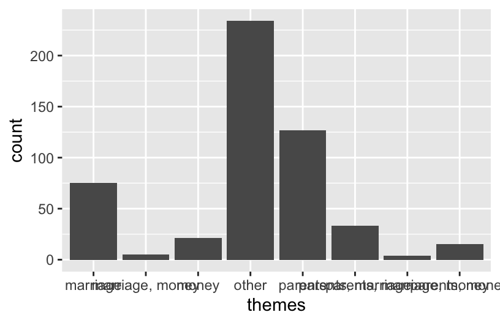

```r
# Adds the bars- Any Problem you notice?
ggplot(abby, aes(x = themes)) +
    geom_bar()
```

```r
# Rotates the x axis labels
ggplot(abby, aes(x = themes)) +
    geom_bar() +
    theme(axis.text.x = element_text(angle = 90, vjust = 0.5, hjust=1))
```

[output not shown]

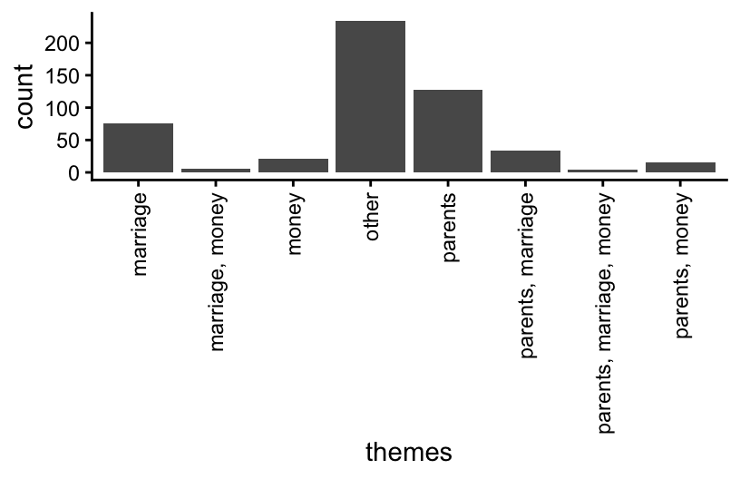

```r
# Changes the visual theme of the plot with a white background and removes gridlines
ggplot(abby, aes(x = themes)) +
    geom_bar() +
    theme_classic() +
    theme(axis.text.x = element_text(angle = 90, vjust = 0.5, hjust=1))
```

## Exercise 4: Exploring sentiment

We’ll look at the distribution of the `bing_pos` sentiment variable and associated summary statistics.

1. The code below creates a **boxplot** of this variable.

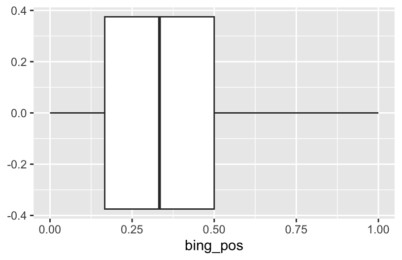

```r
# ???
ggplot(abby, aes(x = bing_pos)) +
    geom_boxplot()
```

2. Using the code for the barplot and boxplot as a guide, try to make a **histogram** and a **density** plot of the overall average ratings.
   - How would you describe the shape of the distribution?

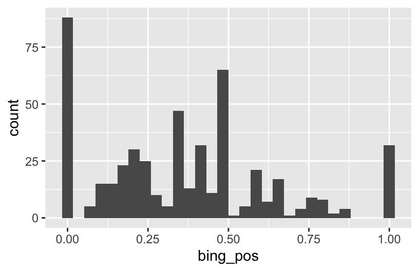

```r
# Histogram
ggplot(abby, aes(x = bing_pos)) +
    geom_histogram()
```

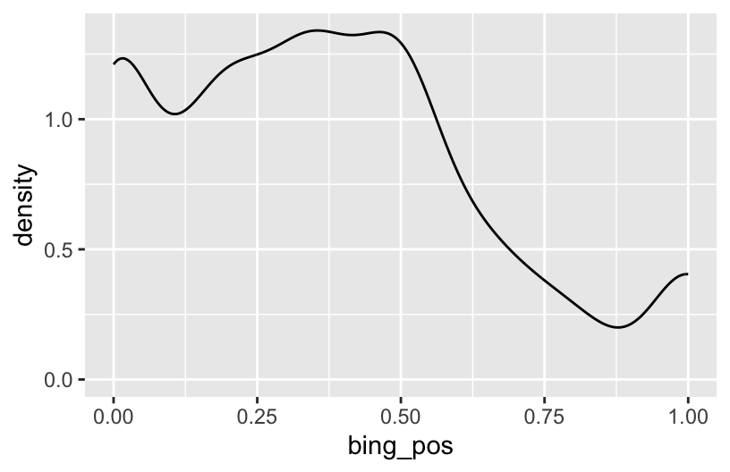

```r
# Density plot
ggplot(abby, aes(x = bing_pos)) +
    geom_density()
```

3. We can compute summary statistics (numerical summaries) for a quantitative variable using the `summary()` function or with the `summarize()` function from the `dplyr` package. (`1st Qu.` and `3rd Qu.` stand for first and third quartile.) After inspecting these summaries, look back to your boxplot, histogram, and density plot. Which plots show which summaries most clearly?

```r
# Summary statistics
# Using summary() - convenient for computing many summaries in one command
# Does not show the standard deviation
abby %>%
    select(bing_pos) %>%
    summary()
##     bing_pos
##  Min.   :0.0000
##  1st Qu.:0.1667
##  Median :0.3333
##  Mean   :0.3650
##  3rd Qu.:0.5000
##  Max.   :1.0000
##  NA's   :19

# Using summarize() from dplyr
# Note that we use %>% to pipe the data into the summarize() function
# We need to use na.rm = TRUE because there are missing values (NAs)
abby %>%
    summarize(mean(bing_pos, na.rm = TRUE), median(bing_pos, na.rm = TRUE), sd(bing_pos, na.rm = TRUE))
## # A tibble: 1 × 3
##   `mean(bing_pos, na.rm = TRUE)` median(bing_pos, na.rm…¹ sd(bing_pos, na.rm =…²
##                            <dbl>                    <dbl>                  <dbl>
## 1                          0.365                    0.333                  0.279
## # ℹ abbreviated names: ¹`median(bing_pos, na.rm = TRUE)`,
## #   ²`sd(bing_pos, na.rm = TRUE)`
```

> Boxplot shows min, max, median, 1st and 3rd quartile easily. (It shows median, 1st and 3rd quartile directly as lines)

> Histogram and density plot show min and max but the mean and median aren’t shown directly–we have to roughly guess based on the peak of the distribution
4. Write a good paragraph describing the information in the histogram (or density plot) by discussing shape, center, spread, and outliers. Incorporate the numerical summaries from part c.

> The distribution of sentiment scores is roughly tri-modal, ranging from 0 to 1. There’s a group of very negative letters (with roughly 0% of words being positive), a group of very positive letters (with roughly 100% of words being positive), and a group of mostly negative letters. The typical sentiment is around 0.34.